# IS 470 Lab 8: Clustering

You have been given a data file by the San Francisco Bay Area Rapid Transit (BART), which identifies a set of demographics for residents in a local area. We will use this file to determine residents segmentations so that we can use it to develop marketing plans accordingly.  
VARIABLE DESCRIPTIONS:  
Age:

```
        1.   14 thru 17
        2.   18 thru 24
        3.   25 thru 34
        4.   35 thru 44
        5.   45 thru 54
        6.   55 thru 64
        7.   65 and Over
```

DistToWork: Distance to work in miles  
DualInc: Is dual income household or not  
Education:

```
        1. Grade 8 or less<br>
        2. Grades 9 to 11<br>
        3. Graduated high school<br>
        4. 1 to 3 years of college<br>
        5. College graduate<br>
        6. Grad Study<br>
```

Gender: M or F  
Income:

```
        1. Less than $10,000<br>
        2. $10,000 to $14,999<br>
        3. $15,000 to $19,999<br>
        4. $20,000 to $24,999<br>
        5. $25,000 to $29,999<br>
        6. $30,000 to $39,999<br>
        7. $40,000 to $49,999<br>
        8. $50,000 to $74,999<br>
        9. $75,000 or more<br>
```

Language: Language spoken at home  
NbrInHouseHold: Number in household  
NbrInHouseholdUnder18: Number in household under 18 years old  
OwnRent: Own, rent, or live with parents  
YrsInArea: Years lived in bay area  
Rider: No, Non-rider; Yes, Rider

### 1. Upload and clean data

```python
# Mounting Google Drive
from google.colab import drive
drive.mount('/content/drive')
```

```python
# Import libraries
import pandas as pd
from sklearn.cluster import KMeans
from collections import Counter
from sklearn import preprocessing
from matplotlib import pyplot as plt
```

```python
# Read data
BartRider = pd.read_csv("/content/drive/MyDrive/IS470_data/BartRider.csv")
BartRider
```

|  | Age | DistToWork | DualInc | Education | Gender | Income | Language | NbrInHouseHold | NbrInHouseholdUnder18 | OwnRent | YrsInArea | Rider |
| --- | --- | --- | --- | --- | --- | --- | --- | --- | --- | --- | --- | --- |
| 0 | 7 | 14 | N | 3 | F | 3 | English | 1 | 0 | Rent | 5 | Yes |
| 1 | 7 | 10 | N | 5 | M | 8 | English | 2 | 0 | Own | 5 | No |
| 2 | 3 | 9 | N | 3 | M | 1 | English | 1 | 0 | Rent | 5 | Yes |
| 3 | 1 | 13 | N | 2 | M | 1 | English | 5 | 3 | Parent | 5 | Yes |
| 4 | 3 | 14 | N | 5 | F | 2 | English | 3 | 1 | Parent | 5 | Yes |
| ... | ... | ... | ... | ... | ... | ... | ... | ... | ... | ... | ... | ... |
| 5488 | 3 | 11 | Y | 4 | M | 5 | English | 2 | 0 | Own | 5 | Yes |
| 5489 | 4 | 9 | Y | 3 | F | 6 | English | 3 | 1 | Rent | 2 | Yes |
| 5490 | 2 | 7 | N | 4 | M | 2 | English | 1 | 1 | Rent | 1 | Yes |
| 5491 | 3 | 7 | Y | 3 | F | 9 | English | 2 | 0 | Own | 5 | No |
| 5492 | 2 | 10 | N | 4 | F | 1 | English | 4 | 2 | Parent | 2 | Yes |

5493 rows × 12 columns

```python
# Show the head rows of a data frame
BartRider.head()
```

|  | Age | DistToWork | DualInc | Education | Gender | Income | Language | NbrInHouseHold | NbrInHouseholdUnder18 | OwnRent | YrsInArea | Rider |
| --- | --- | --- | --- | --- | --- | --- | --- | --- | --- | --- | --- | --- |
| 0 | 7 | 14 | N | 3 | F | 3 | English | 1 | 0 | Rent | 5 | Yes |
| 1 | 7 | 10 | N | 5 | M | 8 | English | 2 | 0 | Own | 5 | No |
| 2 | 3 | 9 | N | 3 | M | 1 | English | 1 | 0 | Rent | 5 | Yes |
| 3 | 1 | 13 | N | 2 | M | 1 | English | 5 | 3 | Parent | 5 | Yes |
| 4 | 3 | 14 | N | 5 | F | 2 | English | 3 | 1 | Parent | 5 | Yes |

```python
# Examine variable type
BartRider.dtypes
```

```
Age                       int64
DistToWork                int64
DualInc                  object
Education                 int64
Gender                   object
Income                    int64
Language                 object
NbrInHouseHold            int64
NbrInHouseholdUnder18     int64
OwnRent                  object
YrsInArea                 int64
Rider                    object
dtype: object
```

```python
# Change categorical variables to "category"
BartRider['DualInc'] = BartRider['DualInc'].astype('category')
BartRider['Gender'] = BartRider['Gender'].astype('category')
BartRider['Language'] = BartRider['Language'].astype('category')
BartRider['OwnRent'] = BartRider['OwnRent'].astype('category')
BartRider['Rider'] = BartRider['Rider'].astype('category')
```

```python
# Examine variable type
BartRider.dtypes
```

```
Age                         int64
DistToWork                  int64
DualInc                  category
Education                   int64
Gender                   category
Income                      int64
Language                 category
NbrInHouseHold              int64
NbrInHouseholdUnder18       int64
OwnRent                  category
YrsInArea                   int64
Rider                    category
dtype: object
```

### 2. Prepare data set for clustering

```python
# Create dummy variables
BartRider = pd.get_dummies(BartRider, columns=['DualInc','Gender','Language','OwnRent','Rider'], drop_first=True)
BartRider
```

|  | Age | DistToWork | Education | Income | NbrInHouseHold | NbrInHouseholdUnder18 | YrsInArea | DualInc_Y | Gender_M | Language_Other | Language_Spanish | OwnRent_Parent | OwnRent_Rent | Rider_Yes |
| --- | --- | --- | --- | --- | --- | --- | --- | --- | --- | --- | --- | --- | --- | --- |
| 0 | 7 | 14 | 3 | 3 | 1 | 0 | 5 | 0 | 0 | 0 | 0 | 0 | 1 | 1 |
| 1 | 7 | 10 | 5 | 8 | 2 | 0 | 5 | 0 | 1 | 0 | 0 | 0 | 0 | 0 |
| 2 | 3 | 9 | 3 | 1 | 1 | 0 | 5 | 0 | 1 | 0 | 0 | 0 | 1 | 1 |
| 3 | 1 | 13 | 2 | 1 | 5 | 3 | 5 | 0 | 1 | 0 | 0 | 1 | 0 | 1 |
| 4 | 3 | 14 | 5 | 2 | 3 | 1 | 5 | 0 | 0 | 0 | 0 | 1 | 0 | 1 |
| ... | ... | ... | ... | ... | ... | ... | ... | ... | ... | ... | ... | ... | ... | ... |
| 5488 | 3 | 11 | 4 | 5 | 2 | 0 | 5 | 1 | 1 | 0 | 0 | 0 | 0 | 1 |
| 5489 | 4 | 9 | 3 | 6 | 3 | 1 | 2 | 1 | 0 | 0 | 0 | 0 | 1 | 1 |
| 5490 | 2 | 7 | 4 | 2 | 1 | 1 | 1 | 0 | 1 | 0 | 0 | 0 | 1 | 1 |
| 5491 | 3 | 7 | 3 | 9 | 2 | 0 | 5 | 1 | 0 | 0 | 0 | 0 | 0 | 0 |
| 5492 | 2 | 10 | 4 | 1 | 4 | 2 | 2 | 0 | 0 | 0 | 0 | 1 | 0 | 1 |

5493 rows × 14 columns

```python
# Apply minmax normalization
min_max_scaler = preprocessing.MinMaxScaler()
BartRider_normalized = pd.DataFrame(min_max_scaler.fit_transform(BartRider))
BartRider_normalized.columns = BartRider.columns
BartRider_normalized
```

|  | Age | DistToWork | Education | Income | NbrInHouseHold | NbrInHouseholdUnder18 | YrsInArea | DualInc_Y | Gender_M | Language_Other | Language_Spanish | OwnRent_Parent | OwnRent_Rent | Rider_Yes |
| --- | --- | --- | --- | --- | --- | --- | --- | --- | --- | --- | --- | --- | --- | --- |
| 0 | 1.000000 | 0.647059 | 0.4 | 0.250 | 0.000 | 0.000000 | 1.00 | 0.0 | 0.0 | 0.0 | 0.0 | 0.0 | 1.0 | 1.0 |
| 1 | 1.000000 | 0.411765 | 0.8 | 0.875 | 0.125 | 0.000000 | 1.00 | 0.0 | 1.0 | 0.0 | 0.0 | 0.0 | 0.0 | 0.0 |
| 2 | 0.333333 | 0.352941 | 0.4 | 0.000 | 0.000 | 0.000000 | 1.00 | 0.0 | 1.0 | 0.0 | 0.0 | 0.0 | 1.0 | 1.0 |
| 3 | 0.000000 | 0.588235 | 0.2 | 0.000 | 0.500 | 0.333333 | 1.00 | 0.0 | 1.0 | 0.0 | 0.0 | 1.0 | 0.0 | 1.0 |
| 4 | 0.333333 | 0.647059 | 0.8 | 0.125 | 0.250 | 0.111111 | 1.00 | 0.0 | 0.0 | 0.0 | 0.0 | 1.0 | 0.0 | 1.0 |
| ... | ... | ... | ... | ... | ... | ... | ... | ... | ... | ... | ... | ... | ... | ... |
| 5488 | 0.333333 | 0.470588 | 0.6 | 0.500 | 0.125 | 0.000000 | 1.00 | 1.0 | 1.0 | 0.0 | 0.0 | 0.0 | 0.0 | 1.0 |
| 5489 | 0.500000 | 0.352941 | 0.4 | 0.625 | 0.250 | 0.111111 | 0.25 | 1.0 | 0.0 | 0.0 | 0.0 | 0.0 | 1.0 | 1.0 |
| 5490 | 0.166667 | 0.235294 | 0.6 | 0.125 | 0.000 | 0.111111 | 0.00 | 0.0 | 1.0 | 0.0 | 0.0 | 0.0 | 1.0 | 1.0 |
| 5491 | 0.333333 | 0.235294 | 0.4 | 1.000 | 0.125 | 0.000000 | 1.00 | 1.0 | 0.0 | 0.0 | 0.0 | 0.0 | 0.0 | 0.0 |
| 5492 | 0.166667 | 0.411765 | 0.6 | 0.000 | 0.375 | 0.222222 | 0.25 | 0.0 | 0.0 | 0.0 | 0.0 | 1.0 | 0.0 | 1.0 |

5493 rows × 14 columns

## 3. Clustering model

```python
# Build a clustering model with n_clusters = 2. Set random_state=0.
model1 = KMeans(n_clusters=2, random_state=0)
model1.fit(BartRider_normalized)
```

```
KMeans(n_clusters=2, random_state=0)
```

```python
# Generate the cluster labels
model1.labels_
```

```
array([0, 1, 0, ..., 0, 1, 0], dtype=int32)
```

```python
# Show cluster size
Counter(model1.labels_)
```

```
Counter({0: 2334, 1: 3159})
```

```python
# Show cluster centroids
pd.DataFrame({'cluster 1':BartRider[model1.labels_==0].mean(axis=0), 'cluster 2':BartRider[model1.labels_==1].mean(axis=0)})
```

|  | cluster 1 | cluster 2 |
| --- | --- | --- |
| Age | 2.562982 | 4.163976 |
| DistToWork | 11.413882 | 11.533713 |
| Education | 3.209940 | 4.361823 |
| Income | 2.846187 | 6.870529 |
| NbrInHouseHold | 3.255356 | 2.646724 |
| NbrInHouseholdUnder18 | 0.897601 | 0.566635 |
| YrsInArea | 4.239931 | 4.330801 |
| DualInc_Y | 0.063839 | 0.377018 |
| Gender_M | 0.442159 | 0.475783 |
| Language_Other | 0.050557 | 0.014562 |
| Language_Spanish | 0.092545 | 0.027857 |
| OwnRent_Parent | 0.556127 | 0.033238 |
| OwnRent_Rent | 0.269923 | 0.338398 |
| Rider_Yes | 0.976435 | 0.023742 |

Q1. What is the percentage of BART riders for cluster 1 and 2?  
Cluster 1: 97.6435%

Cluster 2: 2.3742%

Q2. Use the attributes information of cluster centers to understand the profile of residents. Interpret each cluster based on your understanding.  
People with younger age, low income, live with parents tend to be the riders.

People with older age, high income, have their own rent or house tend to not be the riders.

```python
# Build a clustering model with n_clusters = 3
model2 = KMeans(n_clusters=3, random_state=0)
model2.fit(BartRider_normalized)
```

```
KMeans(n_clusters=3, random_state=0)
```

```python
# Generate the cluster labels
model2.labels_
```

```
array([0, 1, 0, ..., 0, 1, 2], dtype=int32)
```

```python
# Show cluster size
Counter(model2.labels_)
```

```
Counter({0: 1688, 1: 2343, 2: 1462})
```

```python
# Show cluster centroids
pd.DataFrame({'cluster 1':BartRider[model2.labels_==0].mean(axis=0), 'cluster 2':BartRider[model2.labels_==1].mean(axis=0), 'cluster 3':BartRider[model2.labels_==2].mean(axis=0)})
```

|  | cluster 1 | cluster 2 | cluster 3 |
| --- | --- | --- | --- |
| Age | 3.234005 | 4.699531 | 1.823529 |
| DistToWork | 11.500000 | 11.513871 | 11.413133 |
| Education | 4.051540 | 4.436620 | 2.761286 |
| Income | 4.405806 | 7.128468 | 2.878249 |
| NbrInHouseHold | 2.164692 | 2.777636 | 3.965116 |
| NbrInHouseholdUnder18 | 0.338270 | 0.629962 | 1.257182 |
| YrsInArea | 3.776659 | 4.580452 | 4.425445 |
| DualInc_Y | 0.152844 | 0.460094 | 0.002736 |
| Gender_M | 0.563389 | 0.410158 | 0.426129 |
| Language_Other | 0.026659 | 0.015792 | 0.056088 |
| Language_Spanish | 0.051540 | 0.030730 | 0.099179 |
| OwnRent_Parent | 0.000000 | 0.014085 | 0.937073 |
| OwnRent_Rent | 0.997630 | 0.006402 | 0.000000 |
| Rider_Yes | 0.385664 | 0.156637 | 0.913817 |

Q3. Assign a meaningful name to each cluster based on the representative profile of residents in each cluster. Explain the reasons for the name you choose.  
Cluster 1: Young professionals because they have median age, median income, median education, and have their own rent.

Cluster 2: Managers because they have older age, highest income, highest education, and have their own house.

Cluster 3: Students because they have younger age, lowest income, lowest education., and living with parents.

Q4. Based on the cluster size and centroids, which n_clusters (n_clusters=2 or n_clusters=3) you will use, and why?

n_clusters=3 because it clusters the data into a more meaningful group than n_clusters=2.

n_clusters=2 seems like it misses a market segment due to a high difference in the income.

Because the representative profiles of each cluster is more distinct when set n_clusters=3 , especially on income, age, and ownrent. The distinct profiles can facilitate effective marketing plans.

Q5. If we segment residents into 3 clusters, what marketing plans you can use to target each cluster?  
Cluster 1: Young professionals we can use job discount or provide them with some benefits so that we can still keep them using the bartrider. *Emphasize the convenience of BART and marketing on social platform.*

Cluster 2: Managers we can provide them with more benefits when using the bartrider so that we can convince them to be a more frequent riders. *Emphasize the safety of using BART. Take BART will save time, so you can spend more time with family. Taking BART help reduce emission and protect the environment.*

Cluster 3: Students we can use student discount since they are already a frequent riders.

## 4. Elbow test to determine optimal number of clusters

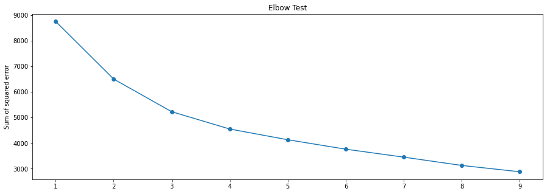

```python
Sum_of_squared_error = []
for k in range(1, 10):
    kmeans = KMeans(n_clusters=k)
    kmeans.fit(BartRider_normalized)
    Sum_of_squared_error.append(kmeans.inertia_)

fig = plt.figure(figsize=(15, 5))
plt.scatter(range(1, 10), Sum_of_squared_error)
plt.plot(range(1, 10), Sum_of_squared_error)
plt.ylabel('Sum of squared error')
plt.title('Elbow Test')
```

Q5. What is the optimal cluster number?  
3.

```python
!jupyter nbconvert --to html "/content/drive/MyDrive/IS470_lab/IS470_lab8.ipynb"
```